# Homework 3

Sana Khan

2022-10-23

I consulted with our textbook to produce the below materials

2**.Use the summary(ChickWeight) command to reveal basic information about the ChickWeight data set. You will find that ChickWeight contains four different variables. Name the four variables. Use the dim(ChickWeight) command to show the dimensions of the ChickWeight data set. The second number in the output, 4, is the number of col‐ umns in the data set, in other words the number of variables. What is the first number? Report it and describe briefly what you think it signifies.**

```r
summary(ChickWeight)
```

```
##      weight           Time           Chick     Diet
##  Min.   : 35.0   Min.   : 0.00   13     : 12   1:220
##  1st Qu.: 63.0   1st Qu.: 4.00   9      : 12   2:120
##  Median :103.0   Median :10.00   20     : 12   3:120
##  Mean   :121.8   Mean   :10.72   10     : 12   4:118
##  3rd Qu.:163.8   3rd Qu.:16.00   17     : 12
##  Max.   :373.0   Max.   :21.00   19     : 12
##                                  (Other):506
```

```r
dim(ChickWeight)
```

```
## [1] 578   4
```

The four variables in the ChickWeight Data set are; Weight, Time, Chick and Diet. The first number, 578, represents the number of observations, or the number of rows in the data set.

**3 Run the following commands, say what the command does, report the output, and briefly explain each piece of output:**

The summary command is showing some of the central tendency and the range of values for the weight variable.

```
##    Min. 1st Qu.  Median    Mean 3rd Qu.    Max.
##    35.0    63.0   103.0   121.8   163.8   373.0
```

```r
head(ChickWeight$weight)
```

```
## [1] 42 51 59 64 76 93
```

The mean is showing us the average weight for a chick. The output is 122

```r
mean(ChickWeight$weight)
```

```
## [1] 121.8183
```

myChkWts is assigning all of the values for the weight variable to this new variable.

```r
myChkWts <- ChickWeight$weight
```

The quantile command breaks up our dataset into sections. In this case we are looking for the .5 or the median piece, which is 103

```r
quantile(myChkWts,0.50)
```

```
## 50%
## 103
```

[output not shown]

#7 Redo Exercise 5, but this time use a sample size of n = 100 (instead of the original sample size of n = 11 used in Exercise 5). Explain why the 2.5% and 97.5% quantiles are different from the results you got for Exercise 5. As a hint, think about what makes a sample “better.”

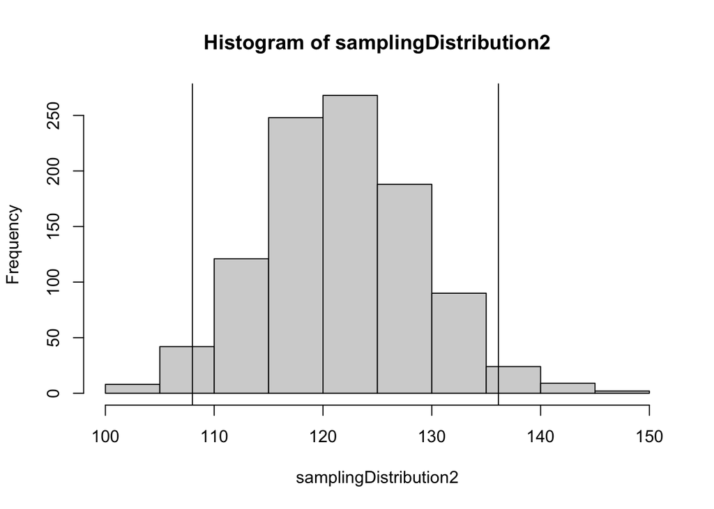

```r
samplingDistribution2 <- replicate(1000,mean(sample(myChkWts,                                   size=100,replace=TRUE)),simplify=TRUE)

hist(samplingDistribution2)

abline(v=quantile(samplingDistribution2,0.025))

abline(v=quantile(samplingDistribution2,0.975))
```

The results are different because this is a larger population size so it has less outliers. A “better” sample would be a lerger sample since it’s more representative of the population